# RSAT matrix-clustering radial tree example

Jaime Abraham Castro-Mondragon

Last update: 2023-07-17

$~$ $~$

# RSAT *matrix-clustering*

RSAT *matrix-clustering* (1) is a software to cluster and align Transcription Factor binding motifs. Here is a brief description of the method:

- Motif comparison: The motifs are compared to each other using two comparison metrics (pearson correlation coeficient (*cor*) and a alignment-width correction (normalized pearson correlation (*Ncor*)).
- Hierarchical clustering: The motifs are hierarchically clustered based in the values of a comparison metric (default = Ncor) .
- Tree partition: the hierarchical tree is partitioned by calculating the average cor and Ncor values at each node, each time a node does not satisfy the thresholds (one value for cor and another for Ncor) the node is split in two clusters.
- Motif alignment: for each cluster, the motifs are progressively aligned following the linkage order of the hierarchical tree, this ensures that each motif is aligned in relation to its most similar motif in the cluster.

We recently updated the algorithm to a [stand-alone version](https://github.com/jaimicore/matrix-clustering_stand-alone) with novel features, for exampke to enable a radial tree visualization, you can find many examples within the JASPAR (2) database [website](https://jaspar.genereg.net/matrix-clusters/) (click on the *Radial tree* buttons).

This is a supporting repository of the [RSAT matrix-clustering stand-alone repository](https://github.com/jaimicore/matrix-clustering_stand-alone). Here you will find an example to reproduce the [JASPAR nematodes radial tree](https://jaspar.genereg.net/matrix-clusters/nematodes/), containing 43 motifs corresponding to 12 TF classes.

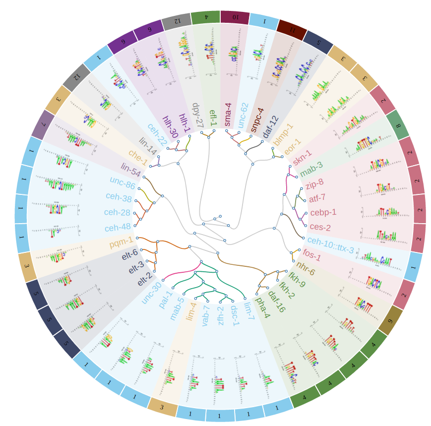

Figure 1. JASPAR nematodes motifs clustered and aligned in a radial tree. The color ring and its number represent different TF classes.

$~$ $~$

# Run RSAT matrix-clustering

We assume you already downloaded and prepared the [RSAT matrix-clustering stand-alone repository](https://github.com/jaimicore/matrix-clustering_stand-alone).

## Generate a radial tree

Run the **example 2** provided in the [RSAT matrix-clustering stand-alone repository](https://github.com/jaimicore/matrix-clustering_stand-alone).

You can run it using the following command:

$~$

```bash
Rscript matrix-clustering.R                                                         \
  -i matrix-clustering_stand-alone_data/JASPAR_2022/Jaspar_nematodes_motifs_tab.txt \
  -o results/JASPAR_nematodes_radial/JASPAR_nematodes                               \
  -a matrix-clustering_stand-alone_data/JASPAR_2022/JASPAR_nematodes_metadata.txt   \
  --radial_tree TRUE                                                                \
  -w 8
```

$~$

**NOTE**: the folder `matrix-clustering_stand-alone_data` is part of the [RSAT matrix-clustering stand-alone repository](https://github.com/jaimicore/matrix-clustering_stand-alone).

**NOTE**: the input files (motifs and annotation table) are provided and described the [RSAT matrix-clustering stand-alone repository](https://github.com/jaimicore/matrix-clustering_stand-alone).

$~$ $~$

## Install `apache`

To install `apache` you can follow this [instructions](https://ubuntu.com/tutorials/install-and-configure-apache#1-overview).

Once `apache` is installed in your computer:

$~$

```bash
sudo rm -rf /var/www/html

sudo cp -r data/JASPAR_2022_CORE_nematodes_matrix-clustering /var/www/html/JASPAR_2022_CORE_nematodes_matrix-clustering
```

$~$

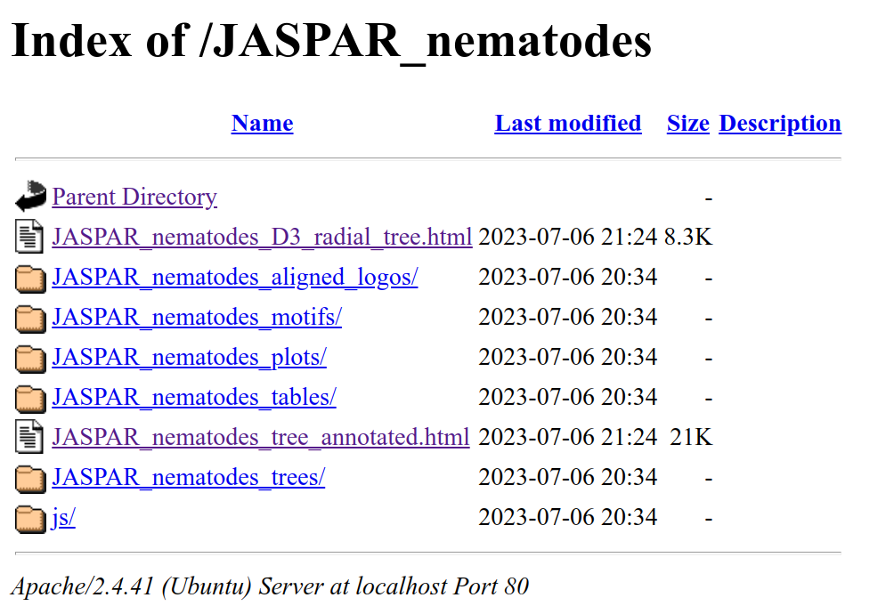

Figure 2. As a localhost, open the *_tree_annotated.html.

$~$ $~$

After running this step, you will see the resulting tree as in Figure 3.

This example will take ~2 minutes, but keep in mind that the running time varies according to the number of input motifs.

Briefly, this radial tree contains the following elements (from inside to outside):

- Hierarchical tree
- The colors in the tree branches correspond to the clusters identified by RSAT *matrix-clustering*.
- Motif IDs (or TF names)
- Motif logo
- Legend (Color::Category::Number)

$~$

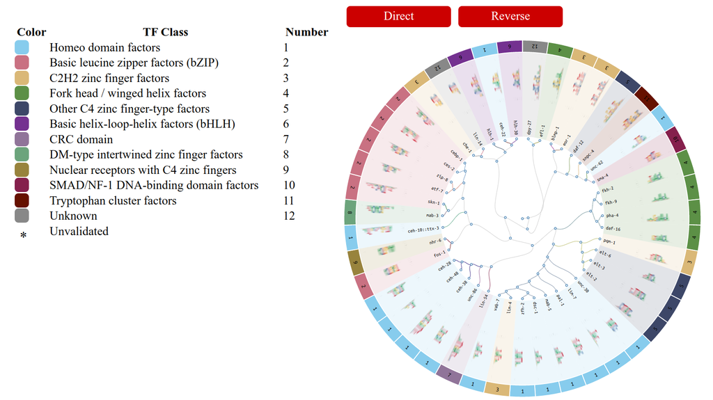

Figure 3. Radial tree with outter ring with annotations and legend table after running the Example 2 of the stand-alone version.

$~$ $~$

## Manual customization

In the following sections we will show what to do to customize the tree in Figure 3, this may be needed to improve the figure readability.

We will modify the next features:

```
1. Font size (Figure 4)
2. Space between motif names and logos (Figure 5)
3. Logo size (Figure 6)
4. Align logo with text (Figure 7)
5. Tree branches thickness (Figure 8)
```

To do these changes, open the file `data/JASPAR_nematodes_tree_annotated.html` with a text editor change the parameters indicated in the following sections.

$~$

### Font size

$~$

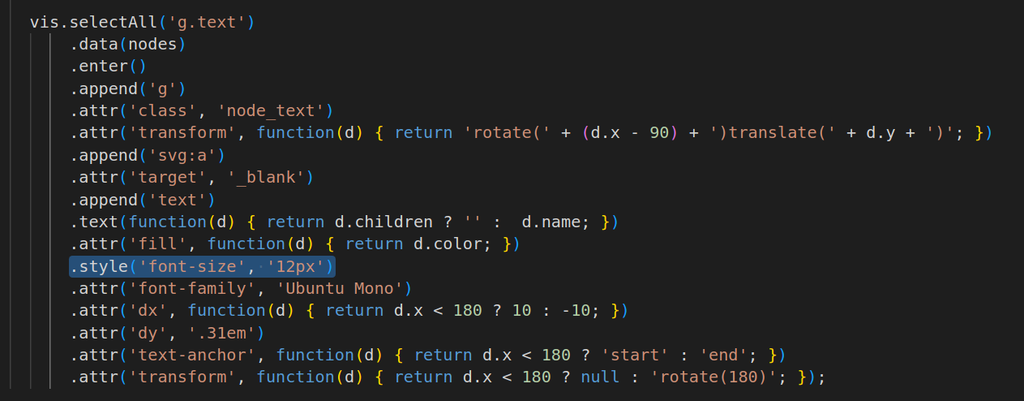

Figure 4. Change the number in the ‘font-size’ parameter. Default: 12.

$~$

### Space between motif names and logos

$~$

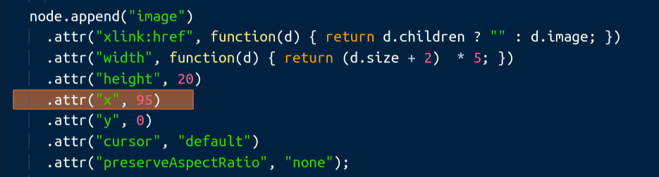

Figure 5. Modify the ‘x’ attribute to adapt the distance between the logo and the motif id. Default: 70.

$~$

### Logo size

$~$

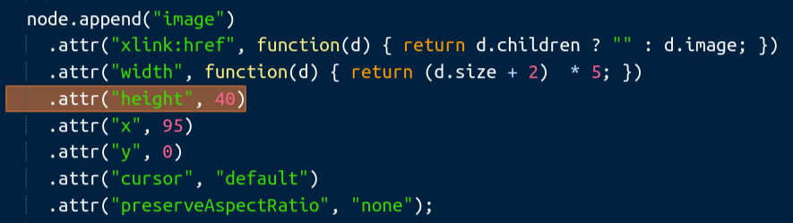

Figure 6. Modify the ‘height’ attribute to adapt the logo size. Default: 20.

$~$

### Align logo with text

$~$

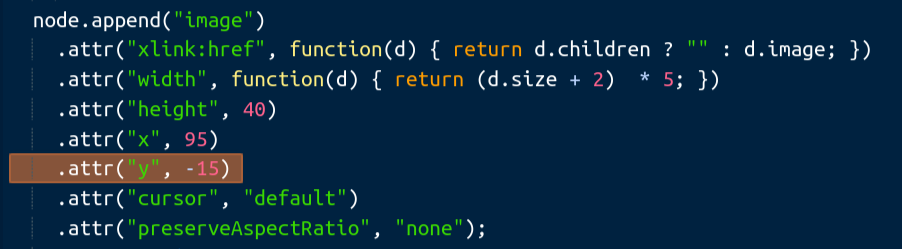

Figure 7. Modify the ‘y’ attribute to move the logo along the Y-axis and align it with the text. Default: 0.

$~$

### Tree branches thickness

$~$

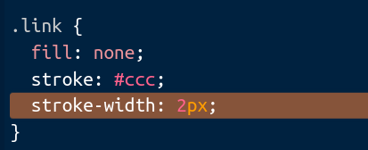

Figure 8. In the CSS section, change the parameter ‘stroke-width’. Default: 1px.

$~$

### Hide legend

$~$

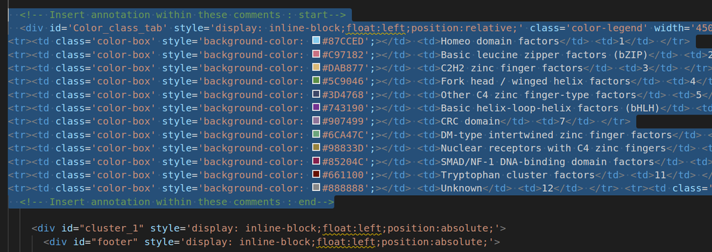

$~$

## Radial tree ready

After all the manual changes, you should see a tree as in Figure 10. Remember that this file can only be visualized in in a folder read by apache.

$~$

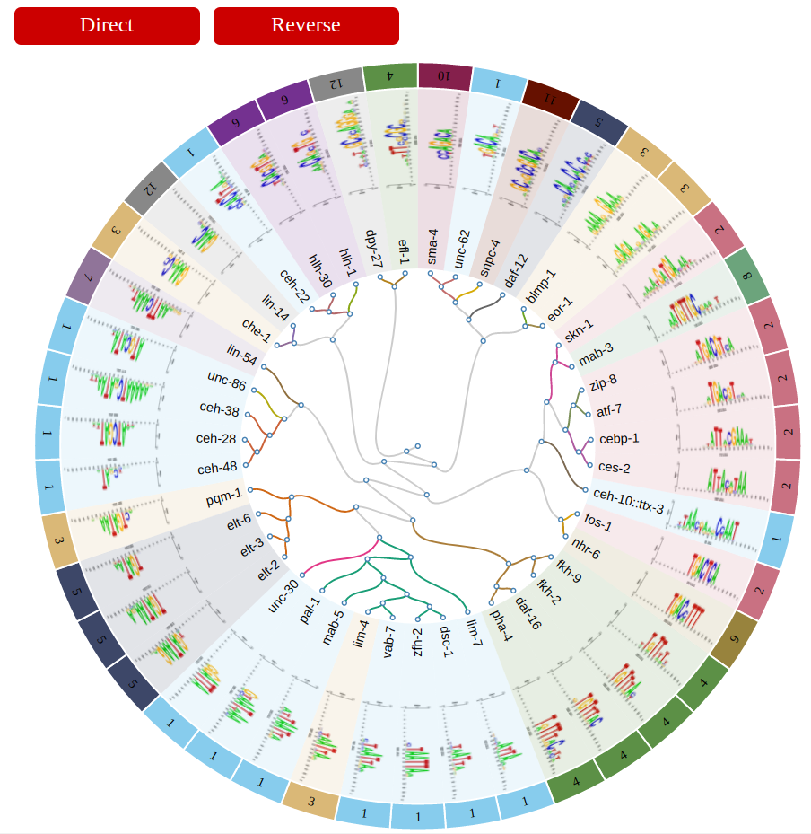

Figure 10. After all the manual changes, the radial tree should look like this one.

$~$

# References

1. Castro-Mondragon,J.A., Jaeger,S., Thieffry,D., Thomas-Chollier,M. and Helden,J. van (2017) [RSAT matrix-clustering: dynamic exploration and redundancy reduction of transcription factor binding motif collections](https://doi.org/10.1093/nar/gkx314). *Nucleic Acids Research*, **45**, e119–e119.

2. Castro-Mondragon,J.A., Riudavets-Puig,R., Rauluseviciute,I., Berhanu Lemma,R., Turchi,L., Blanc-Mathieu,R., Lucas,J., Boddie,P., Khan,A., Manosalva Pérez,N., *et al.* (2021) [JASPAR 2022: the 9th release of the open-access database of transcription factor binding profiles](https://doi.org/10.1093/nar/gkab1113). *Nucleic Acids Research*, **50**, gkab1113–.